# How University of Auckland Students Study

Mustafa Azami

## Visualisation 1: Average Focus Level by Study Method

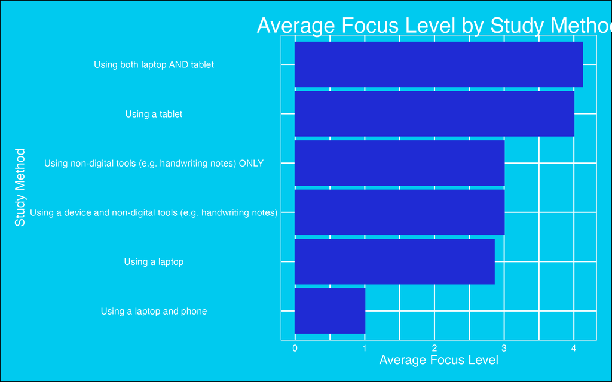

In this graph, I have plotted stuyd method sagainst average focus level. This was done to see which study method is associated with the highest level of focus and which study method is associated with the lowest. Here, it is observed that individuals studying with both a laptop and tablet, are shown to have a average focus level of ~4+, which is the highest focus level out of all study methods. Suggesting individuals using both of these devices, are immersing themselves greatly into their studies, hence why they have both a laptop and tablet in use. On the other hand, individuals using a laptop and phone were observed to have the lowest average focus level out of all the study methods. This is likely due to individuals using their phones as distractions from studying, even if they have their school work in front of them (such as a laptop). This shows that even though both of these study methods involve the use of 2 devices, one study method shows a much higher focus level than the other study method. In between these extremes, we can see study methods including non-digital notes to have mid-range average focus levels (focus levels of ~3), which is likely explained by the fact that by using non-digital notes, there are less distractions from devices. However, still does not have a.focus level as high as that of 2 devices, intended for study (such as the laptop and tablet study method).

## Visualisation 2: Most Common Study Methods

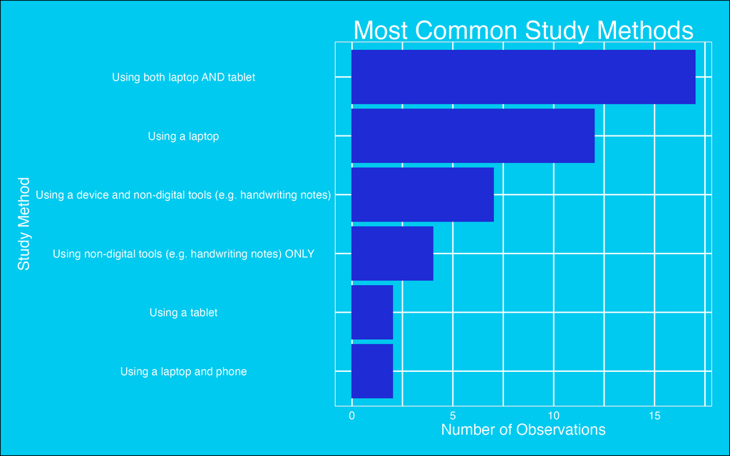

In this graph, I have plotted study methods, along with the number of observations of each study methods, by means of identifying the most common study methods and preffered study methods students use. It is observed here that the study method involving the use of both a laptop and tablet (17 observations), turned out to be the most popular and common study method. Indicating the growing need for students to work digitally, as technology advances and the university digitizes their academic resources (such as lectures, course books, etc.). The second most common was the study method involving use of a laptop (12 observations), suggesting that laptops are of greater use to students, than say tablets, which according to my observations, was used by itself in 2 observations. Suggesting students would rather use tablets, alongside laptops, to better maximise productivity.

## Visualisation 3: Devices Used vs Focus Level

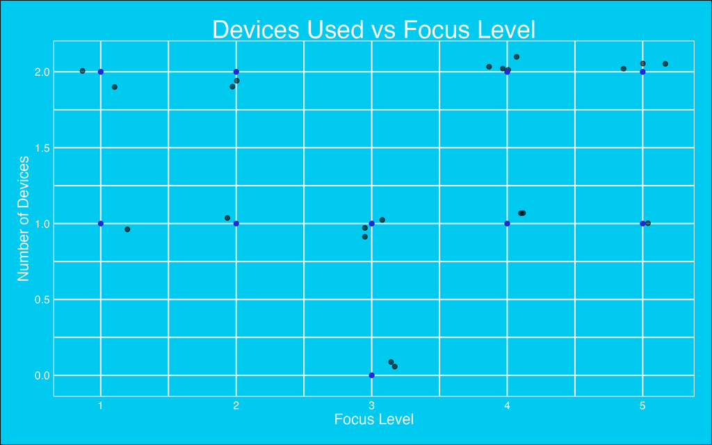

In this graph, I have plotted the number of devices used, against focus level. This builds off from my Visualisation 1 (Average Focus Level by Study Method), to further provide insight on whether the number of devices being used to study at once by students, has an impact on their focus and immersion into tehir studies. It is observed here that the the results for no devices shows that focus levels are within the mid-range of focus (~3), the results for study methods involving 1 devices are highkly varied (suggesting no significance), and the results for study method sinvolving 2 devices is closer to the extremes than in study methdos involving 1 device. however, there are more observations on the higher levels of focus (4-5) in the 2 device study methods, than there are in the lower levels of focus (1-2), indicating it is still a highly preferred and productive study method. Therefore, the number of devices being used to study at once, does have somewhat of an impact on focus levels. However, it highly depends on the method of study. Looking back to Visualisation 1, for example, the study method that showed the lowest level of focus (Using a laptop and phone), and the study method that showed the highest level of focus (Using both a laptop AND tablet), were both study methods involving the use of 2 devices. Therefore, indicating that average focus level is more dependant on the study method, than the number of devices being used to study at once.

## Visualisation 4: Number of Individuals Studying vs Time (Hrs)

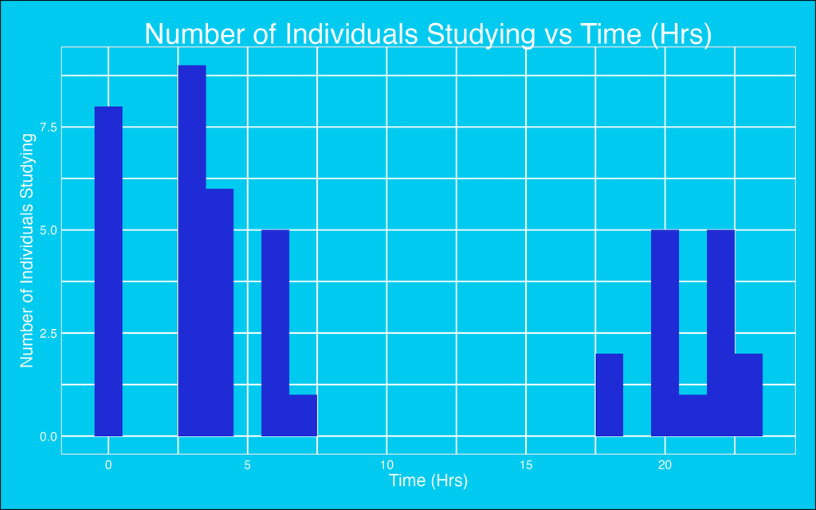

In this graph, I have plotted the number of individiuals studying against time (in hours). This data was based off the time the observations were taken. This plot shows what time students preferred to study. It was observed that students often preferred to study either in the morning, or late afternon to evening (therefore, either extremes). This is potentially the case due to the following factors: eating lunch in the middle of the day, some students may have work either in the morning or evening, or someone students may have classes early in the morning or later in the day, some students could perhaps prefer to study in the morning and some students may prefer to study later in the day in the afternoon or evening.